# Executive Summary: An Analysis of Avocados

Final Project  
Data Science 2 with R (STAT 301-2)

Author

Valerie Chu

Published

March 13, 2024

**Github Repo Link**

https://github.com/stat301-2-2024-winter/final-project-2-valerieyichu.git

## Purpose

I love avocados. Using this [Avocado Prices dataset on Kaggle](https://www.kaggle.com/datasets/neuromusic/avocado-prices) [^1], I want to predict the average price of a single avocado (`average_price`) so that I can pinpoint and eventually move to a city with the cheapest avocados…

<sup>1</sup> Kiggins, Justin. “Avocado Prices.” Kaggle, 2018, https://www.kaggle.com/datasets/neuromusic/avocado-prices.

## Major Takeaways

### About The Target Variable

There was no missingness to this dataset with 18,249 observations, so after a 70/30 split and resampling (10 folds, 5 repeats), this dataset was good to go. This is a regression problem with RMSE as the assessment metric.

Figure 1 shows that average price is a bit right skewed but not enough to warrant a transformation. It has a few outliers spanning the $2.50 to $3.25 per avocado range. The cheapest average price of an avocado is $0.44, and the most expensive average price of an avocado is $3.25.

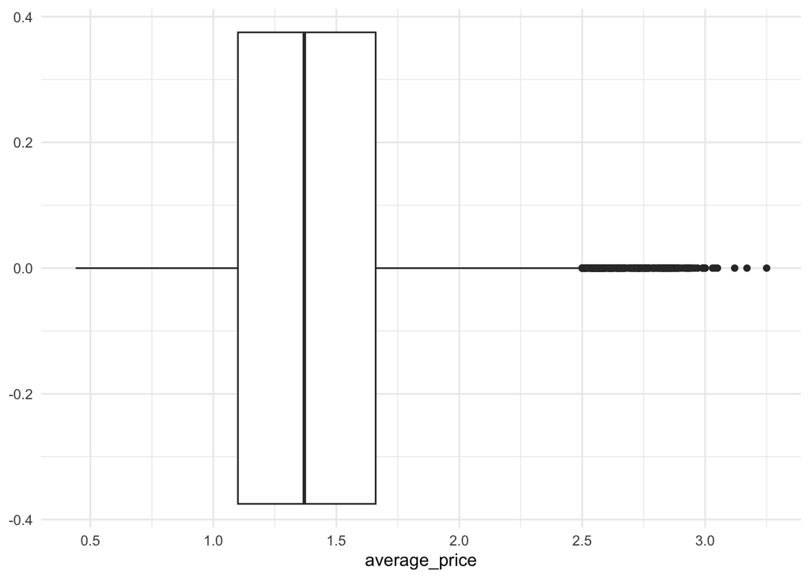

Figure 1: What is the distribution of the average price of a single avocado?

### Recipes and Results

I used the following model types: Null (baseline model), OLS, Lasso, Ridge, Boosted Tree, K Nearest Neighbors, and Random Forest.

I used two recipes for each model type, a kitchen sink recipe (a simple, general recipe) and a feature engineered recipe (a recipe informed by my exploratory data analysis of the target variable, average price, and other variables in the dataset).

Table 1 shows the model results, where Model Types ending in “_2” used the feature engineered recipe:

Table 1: The RMSE and Standard Errors of All Models

| Model Type | RMSE | Std Error | Num Computations |
| --- | --- | --- | --- |
| rf | 0.1741050 | 0.0008874 | 50 |
| knn | 0.1997596 | 0.0011066 | 50 |
| bt | 0.2123226 | 0.0008106 | 50 |
| lasso | 0.3003404 | 0.0009083 | 50 |
| lm | 0.3003657 | 0.0009079 | 50 |
| ridge | 0.3014926 | 0.0008964 | 50 |
| null | 0.3988374 | 0.0007374 | 50 |
| rf_2 | 0.1749338 | 0.0008947 | 50 |
| bt_2 | 0.2131956 | 0.0008083 | 50 |
| knn_2 | 0.2373078 | 0.0009863 | 50 |
| lasso_2 | 0.2993330 | 0.0009000 | 50 |
| lm_2 | 0.2993895 | 0.0008983 | 50 |
| ridge_2 | 0.3006146 | 0.0008907 | 50 |
| null_2 | 0.3988374 | 0.0007374 | 50 |

Figure 2 and Table 2 below show that the best hyperparameters for the kitchen sink random forest model are mtry = 7, min_n = 2

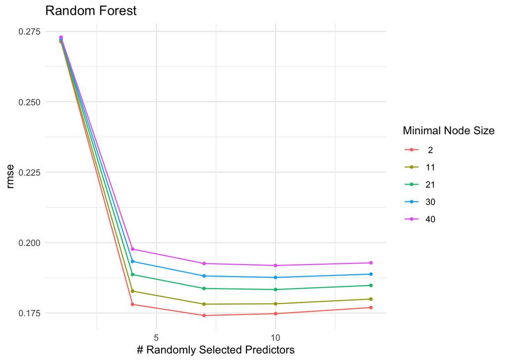

Figure 2: An Autoplot of the Kitchen Sink Random Forest Model

Table 2: The Best Hyperparameters for the Kitchen Sink Random Forest Model

| mtry | min_n | .config |
| --- | --- | --- |
| 7 | 2 | Preprocessor1_Model03 |

### The Final Fit

Table 3 shows the fit of the final model (the kitchen sink random forest model) to the testing dataset:

Table 3: The Metrics of the Final Model to the Testing Data

| .metric | .estimator | .estimate |
| --- | --- | --- |
| rmse | standard | 0.1765 |
| rsq | standard | 0.8192 |
| mae | standard | 0.1229 |

The RMSE is low, the RSQ is close to 1, and the MAE is close to 0. That means the final model did quite well in predicting average price using the testing dataset.

Figure 3 also shows predictions vs. true values:

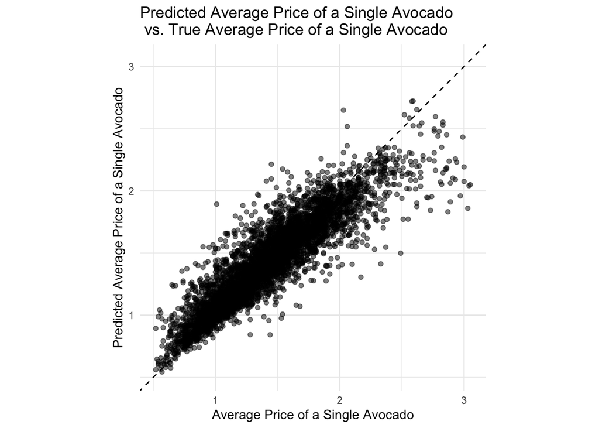

## Conclusion

The kitchen sink random forest model was the best predictive model out of all model types (Null (baseline model), OLS, Lasso, Ridge, Boosted Tree, K Nearest Neighbors, and Random Forest) and across both the kitchen sink and feature engineered recipes.

In the future, I want to boost the predictive accuracy of this model and work with updated data to predict the average price of a single avocado based on the variables in this dataset. I’ve accomplished my goal of predicting the average price of a single Haas avocado sold between 2015 and 2018, and now I just need an even more accurate model and an even more updated dataset to pin down the city I want to move to in 2026, a city with the cheapest avocados…